# SOLITOF - Analyse statistique

## 10.3 Modèle Cox principal

Le modèle principal comprend quatre variables définies a priori :

- ACLF worsening ;
- donor risk index ;
- délai inscription-transplantation ;
- BMI.

Le délai inscription-transplantation est exprimé par **30 jours supplémentaires** afin de fournir une estimation cliniquement interprétable.

**NotePourquoi exprimer le délai par 30 jours ?**

La variable originale `delay_inscrip_TH` correspond au nombre de jours entre l’inscription sur liste et la transplantation.

Dans les modèles, elle est divisée par 30 (`delay_30d`) afin que le hazard ratio corresponde à **30 jours supplémentaires d’attente**, plutôt qu’à un seul jour.

Cette transformation ne modifie ni le modèle ni sa significativité : elle améliore uniquement l’interprétation clinique.

Par exemple, un HR de **1,13** signifie qu’une augmentation de 30 jours du délai inscription-transplantation est associée à une augmentation d’environ **13 % du hazard**, toutes les autres variables du modèle étant maintenues constantes.

| **Characteristic** | **HR** | **95% CI** | **p-value** |
| --- | --- | --- | --- |
| ACLF worsening |  |  |  |
| Stable/improved | — | — |  |
| Worsening | 5.14 | 1.71, 15.5 | 0.004 |
| Donor Risk Index — par unité | 1.97 | 0.71, 5.46 | 0.2 |
| Délai inscription-TH — par 30 jours | 1.13 | 1.03, 1.23 | 0.007 |
| BMI — par kg/m² | 0.94 | 0.86, 1.02 | 0.15 |

Abbreviations: CI = Confidence Interval, HR = Hazard Ratio

**AvertissementPrécision des estimations**

Le groupe `Worsening` comprend seulement huit patients.

Le modèle principal est donc volontairement parcimonieux. L’interprétation repose sur la magnitude de l’association et son intervalle de confiance, et non uniquement sur la p-value.

# 11 Analyses de sensibilité principales

Trois analyses sont conservées dans le corps principal car elles répondent directement aux principales questions méthodologiques du projet.

## 11.1 Ajustement sur la sévérité initiale à J-2

Le grade ACLF à J-2 est antérieur à la trajectoire étudiée.

Il est donc utilisé pour tester si l’association avec `Worsening` persiste après prise en compte de la sévérité initiale.

Le grade à J0 n’est pas introduit dans ce modèle, car il résulte directement du grade initial et de l’évolution entre J-2 et J0.

| **Characteristic** | **HR** | **95% CI** | **p-value** |
| --- | --- | --- | --- |
| ACLF worsening |  |  |  |
| Stable/improved | — | — |  |
| Worsening | 8.24 | 2.23, 30.5 | 0.002 |
| Grade ACLF J-2 — par grade | 1.65 | 0.79, 3.45 | 0.2 |
| Donor Risk Index | 1.84 | 0.66, 5.12 | 0.2 |
| Âge du receveur | 1.01 | 0.97, 1.05 | 0.6 |

Abbreviations: CI = Confidence Interval, HR = Hazard Ratio

## 11.2 Analyse de l’effet plafond

Les patients déjà ACLF-3 à J-2 ne peuvent pas présenter une augmentation supplémentaire du grade.

L’analyse est donc répétée uniquement chez les patients ACLF-1 ou ACLF-2 à J-2.

Compte tenu du faible nombre d’événements dans cette sous-population, seule l’analyse **non ajustée** est mise en avant dans le corps principal.

Population de l'analyse de l'effet plafond

| Indicateur | N |
| --- | --- |
| Patients ACLF 1-2 à J-2 | 40 |
| Worsening | 8 |
| Stable/improved | 32 |
| Pertes du greffon à 12 mois | 11 |

| **Characteristic** | **HR** | **95% CI** | **p-value** |
| --- | --- | --- | --- |
| ACLF worsening |  |  |  |
| Stable/improved | — | — |  |
| Worsening | 5.14 | 1.55, 17.0 | 0.007 |

Abbreviations: CI = Confidence Interval, HR = Hazard Ratio

## 11.3 Cox pénalisé de Firth

Une régression de Cox pénalisée est utilisée pour vérifier la stabilité de l’estimation dans le contexte du faible effectif du groupe exposé.

Les deux événements enregistrés à J0 sont positionnés à J1 uniquement pour cette analyse, le package `coxphf` nécessitant des temps strictement positifs.

Analyse pénalisée de Firth

| Variable | HR (IC95%) | p |
| --- | --- | --- |
| ACLF worsening | 5.21 (1.66–14.42) | 0.006 |
| Donor Risk Index | 1.92 (0.72–5.42) | 0.196 |
| Délai inscription-TH — 30 jours | 1.11 (1.02–1.18) | 0.021 |
| BMI | 0.94 (0.86–1.02) | 0.154 |

Le HR obtenu par Firth est presque identique à celui du Cox conventionnel, ce qui constitue un argument supplémentaire en faveur de la stabilité du signal observé.

**NoteLecture des sensibilités**

La cohérence de la direction et de la magnitude des estimations entre le modèle principal, l’ajustement sur la sévérité initiale, l’analyse de l’effet plafond et le modèle pénalisé constitue l’élément principal de robustesse.

Les autres analyses sont présentées dans le supplementary material.

# 12 Outcomes secondaires

## 12.1 Mortalité à 12 mois

La mortalité est reconstruite indépendamment de la variable de perte du greffon.

Les patients vivants sont censurés à leurs dernières nouvelles.

MIL G et ABU Z restent exclus de l’analyse standard de survie.

### 12.1.1 Décès selon la trajectoire ACLF

Mortalité à 12 mois

| Trajectoire ACLF | N | Décès à 12 mois | % |
| --- | --- | --- | --- |
| Stable/improved | 93 | 22 | 23.7 |
| Worsening | 8 | 4 | 50.0 |

### 12.1.2 Kaplan-Meier

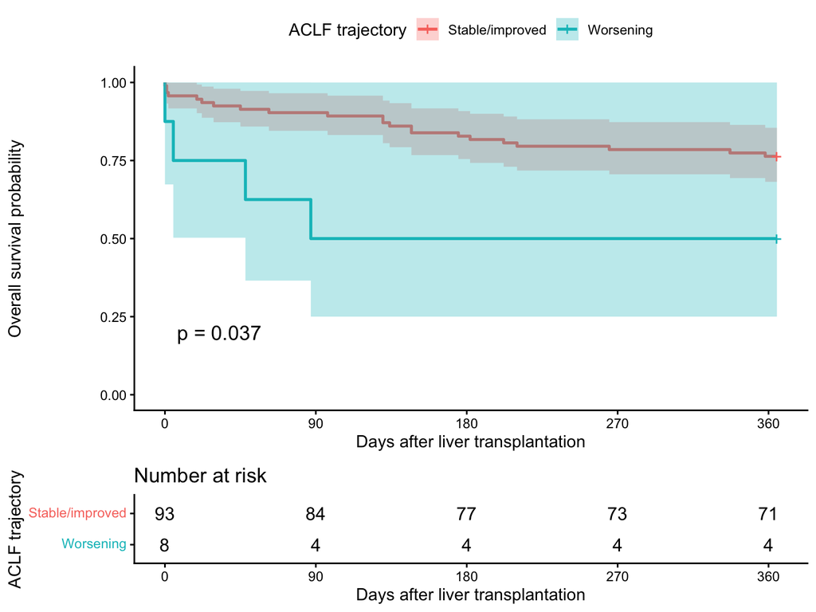

### 12.1.3 Cox ajusté

| **Characteristic** | **HR** | **95% CI** | **p-value** |
| --- | --- | --- | --- |
| ACLF worsening |  |  |  |
| Stable/improved | — | — |  |
| Worsening | 3.50 | 1.09, 11.2 | 0.035 |
| Donor Risk Index | 1.44 | 0.51, 4.05 | 0.5 |
| Délai inscription-TH — par 30 jours | 1.13 | 1.04, 1.24 | 0.004 |
| BMI | 0.93 | 0.85, 1.02 | 0.14 |

Abbreviations: CI = Confidence Interval, HR = Hazard Ratio

## 12.2 Dysfonction précoce du greffon

La dysfonction précoce du greffon est analysée dans la population ACLF de 103 patients.

La variable utilisée est :

`Dysfonction_primaire_de_greffon`

Dysfonction précoce du greffon

| Trajectoire ACLF | N | Dysfonction précoce | % |
| --- | --- | --- | --- |
| Stable/improved | 94 | 14 | 14.9 |
| Worsening | 8 | 1 | 12.5 |

| OR (IC95%) | p |
| --- | --- |
| 0.82 (0.02–7.23) | 1.000 |

## 12.3 Non-fonction primaire du greffon

La non-fonction primaire est rare et analysée uniquement par comparaison exacte entre groupes.

Non-fonction primaire du greffon

| Trajectoire ACLF | N | Non-fonction primaire | % |
| --- | --- | --- | --- |
| Stable/improved | 94 | 2 | 2.1 |
| Worsening | 8 | 1 | 12.5 |

Fisher exact test

| p |
| --- |
| 0.219 |

## 12.4 Complications sévères — Clavien-Dindo ≥3

La variable utilisée est :

`Clavien_≥_3`

Complications postopératoires sévères

| Trajectoire ACLF | N | Clavien-Dindo ≥3 | % |
| --- | --- | --- | --- |
| Stable/improved | 94 | 16 | 17.0 |
| Worsening | 8 | 1 | 12.5 |

| OR (IC95%) | p |
| --- | --- |
| 0.70 (0.01–6.09) | 1.000 |

# 13 Synthèse des résultats

L’analyse principale et les principales analyses de sensibilité sont regroupées dans un tableau unique.

Principales associations avec ACLF worsening

| Analyse | HR (IC95%) | p |
| --- | --- | --- |
| Perte du greffon — modèle principal | 5.14 (1.71–15.49) | 0.004 |
| Perte du greffon — ajustement sévérité J-2 | 8.24 (2.23–30.49) | 0.002 |
| Perte du greffon — ACLF 1-2 uniquement | 5.14 (1.55–17.05) | 0.007 |
| Perte du greffon — Firth | 5.21 (1.66–14.42) | 0.006 |
| Mortalité à 12 mois — ajusté | 3.50 (1.09–11.21) | 0.035 |

**ImportantMessage principal**

Les résultats suggèrent qu’une aggravation du grade ACLF dans les 48 heures précédant la transplantation est associée à une augmentation importante du risque de perte du greffon durant la première année.

L’association reste de même direction après prise en compte de la sévérité initiale, après restriction aux patients susceptibles de présenter une aggravation du grade ACLF et après estimation pénalisée.

Un signal de même direction est observé pour la mortalité à 12 mois.

En revanche, aucune association évidente n’est observée avec la dysfonction précoce du greffon dans les données actuelles.

Compte tenu du très faible effectif du groupe `Worsening`, les estimations restent imprécises et nécessitent une validation externe.

# 14 Supplementary material

Les analyses suivantes sont conservées pour documenter la robustesse méthodologique sans alourdir le corps principal.

## 14.1 Modèle Cox à cinq variables

| **Characteristic** | **HR** | **95% CI** | **p-value** |
| --- | --- | --- | --- |
| Delta_Grade_ACLF_group |  |  |  |
| Stable/improved | — | — |  |
| Worsening | 4.73 | 1.54, 14.5 | 0.007 |
| DRI_model | 1.95 | 0.70, 5.40 | 0.2 |
| delay_30d | 1.13 | 1.03, 1.23 | 0.006 |
| BMI_model | 0.93 | 0.85, 1.02 | 0.12 |
| age_model | 1.02 | 0.98, 1.06 | 0.4 |

Abbreviations: CI = Confidence Interval, HR = Hazard Ratio

## 14.2 Comparaison AIC

| Modele | AIC | Delta_AIC |
| --- | --- | --- |
| 4 variables | 243.04 | 0.00 |
| 5 variables | 244.39 | 1.36 |

**NoteComment lire l’AIC ?**

L’Akaike Information Criterion (AIC) compare le compromis entre **qualité d’ajustement du modèle** et **complexité du modèle**.

À population identique, un AIC plus faible indique un meilleur compromis entre ces deux dimensions.

L’AIC n’est pas une mesure de significativité statistique et ne possède pas de seuil absolu : c’est essentiellement la **différence d’AIC entre deux modèles** qui est informative.

En pratique :

- ΔAIC < 2 : performances considérées comme très proches ;
- ΔAIC entre 4 et 7 : avantage plus marqué pour le modèle ayant l’AIC le plus faible ;
- ΔAIC > 10 : soutien nettement plus important pour le modèle ayant l’AIC le plus faible.

Ici, la différence entre les modèles à quatre et cinq variables est faible. Elle ne justifie donc pas d’augmenter la complexité du modèle principal, qui reste volontairement parcimonieux.

## 14.3 Modèle de sensibilité avec MELD et EER à J0

Cette analyse reproduit l’esprit du modèle discuté historiquement avec Antoine, en incluant une mesure de gravité hépatique et un support d’organe au moment de la transplantation.

Elle ne remplace pas le modèle principal préspécifié.

| **Characteristic** | **HR** | **95% CI** | **p-value** |
| --- | --- | --- | --- |
| ACLF worsening |  |  |  |
| Stable/improved | — | — |  |
| Worsening | 6.29 | 2.10, 18.8 | 0.001 |
| Donor Risk Index | 1.91 | 0.69, 5.27 | 0.2 |
| EER à J0 | 1.41 | 0.57, 3.49 | 0.5 |
| MELD à J0 | 1.03 | 0.97, 1.10 | 0.3 |

Abbreviations: CI = Confidence Interval, HR = Hazard Ratio

## 14.4 Analyse ajustée restreinte aux ACLF 1-2

Cette analyse est considérée comme exploratoire en raison du faible nombre d’événements.

| **Characteristic** | **HR** | **95% CI** | **p-value** |
| --- | --- | --- | --- |
| Delta_Grade_ACLF_group |  |  |  |
| Stable/improved | — | — |  |
| Worsening | 12.9 | 2.39, 69.9 | 0.003 |
| DRI_model | 14.6 | 1.83, 116 | 0.011 |
| delay_30d | 1.11 | 0.53, 2.29 | 0.8 |
| BMI_model | 0.93 | 0.81, 1.05 | 0.2 |

Abbreviations: CI = Confidence Interval, HR = Hazard Ratio

## 14.5 Perte du greffon à 60 mois

| **Characteristic** | **HR** | **95% CI** | **p-value** |
| --- | --- | --- | --- |
| Delta_Grade_ACLF_group |  |  |  |
| Stable/improved | — | — |  |
| Worsening | 4.10 | 1.42, 11.8 | 0.009 |
| DRI_model | 2.17 | 0.88, 5.34 | 0.091 |
| delay_30d | 1.10 | 1.01, 1.20 | 0.028 |
| BMI_model | 0.96 | 0.90, 1.03 | 0.3 |

Abbreviations: CI = Confidence Interval, HR = Hazard Ratio

## 14.6 Perte du greffon — full follow-up

| **Characteristic** | **HR** | **95% CI** | **p-value** |
| --- | --- | --- | --- |
| Delta_Grade_ACLF_group |  |  |  |
| Stable/improved | — | — |  |
| Worsening | 3.39 | 1.19, 9.60 | 0.022 |
| DRI_model | 2.38 | 1.06, 5.33 | 0.035 |
| delay_30d | 1.10 | 1.02, 1.19 | 0.017 |
| BMI_model | 0.95 | 0.89, 1.01 | 0.12 |

Abbreviations: CI = Confidence Interval, HR = Hazard Ratio

## 14.7 Diagnostics du modèle Cox principal

### 14.7.1 Proportionnalité des risques

| Variable | chisq | df | p |
| --- | --- | --- | --- |
| Delta_Grade_ACLF_group | 0.912 | 1.000 | 0.340 |
| DRI_model | 2.535 | 1.000 | 0.111 |
| delay_30d | 1.097 | 1.000 | 0.295 |
| BMI_model | 0.129 | 1.000 | 0.719 |
| GLOBAL | 5.025 | 4.000 | 0.285 |

**NotePourquoi vérifier la proportionnalité des risques ?**

Le modèle de Cox suppose que le rapport des hazards entre deux patients reste approximativement constant au cours du temps.

Cette hypothèse est évaluée à partir des résidus de Schoenfeld.

Une p-value faible suggère que l’effet d’une variable pourrait varier au cours du temps et donc que l’hypothèse de proportionnalité est potentiellement violée.

À l’inverse, une p-value > 0,05 signifie qu’aucun argument statistique clair en faveur d’une violation n’est identifié ; cela ne constitue pas une preuve formelle de proportionnalité.

Le test global évalue simultanément l’ensemble du modèle.

Dans le modèle principal, le test global n’identifie pas de violation significative de l’hypothèse de proportionnalité des risques.

### 14.7.2 Forme fonctionnelle des covariables

| Variable | p non-linéarité |
| --- | --- |
| Donor Risk Index | 0.975 |
| Délai inscription-TH | 0.113 |
| BMI | 0.548 |

**NotePourquoi tester la forme fonctionnelle ?**

Dans le modèle principal, les variables continues sont supposées avoir une relation log-linéaire avec le hazard.

Autrement dit, le modèle suppose par exemple que l’effet associé à 30 jours supplémentaires d’attente est comparable quelle que soit la valeur initiale du délai.

Pour tester cette hypothèse, chaque variable continue est comparée à une représentation plus flexible par spline naturelle.

Une p-value faible en faveur de la spline suggérerait qu’une relation non linéaire décrit mieux les données.

Ici, aucune des covariables continues ne montre d’argument clair en faveur d’une non-linéarité. La forme linéaire, plus parcimonieuse, est donc conservée.

### 14.7.3 Colinéarité des covariables

La colinéarité entre les covariables du modèle principal est évaluée à l’aide des variance inflation factors.

Variance inflation factors — modèle principal

| Variable | VIF |
| --- | --- |
| Delta_Grade_ACLF_group | 1.28 |
| DRI_model | 1.22 |
| delay_30d | 1.08 |
| BMI_model | 1.07 |

**NoteComment interpréter le VIF ?**

Le Variance Inflation Factor (VIF) évalue si plusieurs covariables du modèle apportent une information fortement redondante.

Une forte colinéarité peut rendre les coefficients du modèle instables et élargir artificiellement leurs intervalles de confiance.

À titre de repère :

- VIF proche de 1 : absence de colinéarité notable ;
- VIF entre 2 et 5 : colinéarité généralement modérée ;
- VIF > 5 : colinéarité potentiellement problématique ;
- VIF > 10 : colinéarité importante.

Le VIF est utilisé ici comme un diagnostic du modèle et non comme une procédure automatique d’exclusion des variables.

### 14.7.4 Analyse d’influence du délai inscription-transplantation

Le délai inscription-transplantation présente une distribution asymétrique avec quelques valeurs élevées.

Une analyse de sensibilité est donc réalisée après exclusion des valeurs supérieures au 99e percentile.

Influence des valeurs extrêmes du délai inscription-TH

| Analyse | HR (IC95%) | p |
| --- | --- | --- |
| Modèle principal | 5.14 (1.71–15.49) | 0.004 |
| Exclusion >99e percentile du délai | 4.68 (1.56–14.06) | 0.006 |

**NoteObjectif de cette analyse**

Quelques patients peuvent avoir un délai inscription-transplantation particulièrement long.

Dans une cohorte de taille limitée, ces valeurs extrêmes pourraient exercer une influence disproportionnée sur le coefficient associé au délai et, indirectement, sur les autres coefficients du modèle.

L’analyse est donc répétée après exclusion des valeurs situées au-delà du 99e percentile.

L’objectif n’est pas d’exclure ces patients de l’analyse principale, mais de vérifier que l’association entre `ACLF worsening` et perte du greffon n’est pas principalement déterminée par quelques observations extrêmes.

## 14.8 Modèle exploratoire avec présélection univariée et sélection stepwise AIC

Cette analyse reproduit une stratégie proche de celle utilisée historiquement dans le projet SOLITOF.

Elle comporte deux étapes.

**Étape 1 — présélection univariée**

Chaque covariable candidate est analysée séparément dans un modèle de Cox.

Les covariables présentant une association avec la perte du greffon à `p < 0,20` sont retenues comme candidates pour le modèle multivarié.

Ce seuil volontairement permissif n’est pas utilisé pour conclure à une association statistiquement significative. Il sert uniquement à éviter d’écarter trop précocement une covariable potentiellement informative.

**Étape 2 — sélection multivariée par AIC**

Les variables présélectionnées sont introduites dans un modèle multivarié, puis une procédure stepwise bidirectionnelle recherche le modèle ayant le meilleur compromis entre ajustement aux données et complexité, évalué par l’AIC.

`ACLF worsening` constitue l’exposition d’intérêt et est forcée dans tous les modèles : elle ne peut donc pas être éliminée par la procédure stepwise.

Cette approche est **exploratoire et data-driven**. Elle ne remplace pas le modèle principal à quatre covariables défini a priori. Elle permet de vérifier si une méthode de sélection proche de l’analyse historique conduit à une estimation cohérente de l’effet de `ACLF worsening`.

### 14.8.1 Analyses univariées de présélection

Présélection univariée des covariables

| Variable | N | Events | HR (IC95%) | p | Retenue (p < 0,20) |
| --- | --- | --- | --- | --- | --- |
| age_model | 101 | 28 | 1.02 (0.98–1.06) | 0.414 | FALSE |
| BMI_model | 101 | 28 | 0.93 (0.86–1.02) | 0.114 | TRUE |
| DRI_model | 100 | 28 | 1.49 (0.58–3.83) | 0.413 | FALSE |
| delay_30d | 101 | 28 | 1.11 (1.02–1.21) | 0.020 | TRUE |
| MELD_J0_model | 101 | 28 | 1.03 (0.97–1.09) | 0.292 | FALSE |
| ACLF_baseline_model | 101 | 28 | 1.07 (0.60–1.88) | 0.823 | FALSE |
| EER_J0_model | 101 | 28 | 1.37 (0.62–3.03) | 0.434 | FALSE |
| VM_J0_model | 101 | 28 | 1.47 (0.70–3.10) | 0.305 | FALSE |
| NAD_J0_model | 101 | 28 | 1.12 (0.52–2.43) | 0.767 | FALSE |

### 14.8.2 Construction de la population commune

Pour éviter que l’AIC compare des modèles construits sur des populations différentes, la sélection est réalisée sur une population complete-case commune à toutes les variables présélectionnées.

### 14.8.3 Modèle complet avant sélection AIC

### 14.8.4 Sélection bidirectionnelle par AIC

`ACLF worsening` est forcé dans le modèle minimal et ne peut donc pas être éliminé par la procédure stepwise.

| **Characteristic** | **HR** | **95% CI** | **p-value** |
| --- | --- | --- | --- |
| Delta_Grade_ACLF_group |  |  |  |
| Stable/improved | — | — |  |
| Worsening | 4.89 | 1.80, 13.3 | 0.002 |
| delay_30d | 1.13 | 1.04, 1.23 | 0.005 |

Abbreviations: CI = Confidence Interval, HR = Hazard Ratio

### 14.8.5 Résumé du modèle sélectionné

Résumé de la sélection AIC

| Indicateur | Valeur |
| --- | --- |
| Population complete-case | 101.00 |
| Événements | 28.00 |
| AIC du modèle complet | 243.35 |
| AIC du modèle sélectionné | 243.23 |
| Nombre de coefficients finaux | 2.00 |

**AvertissementLimites de la sélection stepwise**

La sélection stepwise peut produire des modèles instables lorsque le nombre d’événements est limité et peut conduire à des estimations trop optimistes lorsqu’elle est utilisée comme méthode principale.

Elle est donc présentée ici uniquement comme **analyse exploratoire de robustesse**.

Le résultat à privilégier pour l’interprétation et le manuscrit reste celui du modèle principal préspécifié.

**AvertissementInterprétation**

Cette procédure est **data-driven** et doit être interprétée avec prudence compte tenu du nombre limité d’événements et du faible effectif du groupe `Worsening`.

Elle n’est pas utilisée pour définir le modèle principal.

Son intérêt est de vérifier si une procédure de sélection proche de l’analyse historique conduit à une estimation de l’association entre `ACLF worsening` et la perte du greffon cohérente avec le modèle préspécifié.

## 14.9 Mortalité — full follow-up

| **Characteristic** | **HR** | **95% CI** | **p-value** |
| --- | --- | --- | --- |
| Delta_Grade_ACLF_group |  |  |  |
| Stable/improved | — | — |  |
| Worsening | 1.90 | 0.64, 5.63 | 0.2 |
| DRI_model | 2.03 | 0.92, 4.49 | 0.079 |
| delay_30d | 1.11 | 1.02, 1.20 | 0.013 |
| BMI_model | 0.94 | 0.88, 1.00 | 0.055 |

Abbreviations: CI = Confidence Interval, HR = Hazard Ratio

# 15 Annexe interne — différences avec l’analyse historique

> Cette section constitue un audit trail interne et devra être retirée de la version soumise du manuscrit.
1. Trois patients réévalués comme NON-ACLF sont exclus : **106 → 103 patients**.
2. Le groupe `Worsening` passe de **11 à 8 patients**.
3. La population standard de survie comprend **101 patients**.
4. La perte du greffon est reconstruite directement à partir du décès et de la retransplantation.
5. Les patients sans événement sont correctement censurés à leurs dernières nouvelles.
6. L’outcome principal est fixé à **12 mois**.
7. L’analyse à 60 mois et le full follow-up deviennent des analyses complémentaires.
8. Le modèle principal est limité à quatre covariables définies a priori.
9. Le grade ACLF à J-2 est introduit dans une analyse de sensibilité dédiée.
10. L’effet plafond des ACLF-3 est analysé spécifiquement.
11. Une estimation pénalisée de Firth est ajoutée.
12. La mortalité est entièrement reconstruite avec censure correcte des patients vivants.
13. Le délai inscription-transplantation est exprimé par 30 jours.
14. La forme fonctionnelle des covariables et l’hypothèse de proportionnalité sont vérifiées.
15. La dysfonction précoce du greffon, la non-fonction primaire et les complications Clavien-Dindo ≥3 sont analysées comme outcomes secondaires.
16. L’erreur de saisie du délai inscription-transplantation à -5 jours a été corrigée dans la base source à **+5 jours**.